# An Analysis of The COVID-19 Spread in South Africa

#### By Caryn Biebuyck (20715978) and Lauren Downing (19202113)

# Introduction

The intention of this notebook is to reproduce the analysis and visualisations available at Bhekisisa and Media Hack’s [Coronavirus Dashboard](https://mediahack.co.za/datastories/coronavirus/dashboard/). After the setup of the necessary R libraries, a step-by-step approach will be taken for each analysis, starting with the collection of the raw data. In cases where the raw data has already been retrieved, the function to fetch said data will be commented out. Next, the data transformation process will be documented. Finally, the visualisations of the data will be presented. We would like to thank Laura from the Media Hack team for guiding us to relevant data and allowing us to access Media Hack’s CSVs.

```r
  library(directlabels)
  library(gt)
  library(kableExtra)
  library(lubridate)
  library(rvest)
  library(scales)
  library(tidyverse)
  library(zoo)
```

# Data collection

The data used for this analysis was retrieved and thereafter cleaned from sources made available by the [Data Science for Social Impact Research Group](https://github.com/dsfsi/covid19za), [Media Hack](http://mediahack.co.za/datastories/coronavirus/data-release/), the [National Institute for Communicable Diseases](https://www.nicd.ac.za/media/alerts/), and the [European Centre for Disease Prevention and Control](https://github.com/owid/covid-19-data/tree/master/public/data).

```r
# Data from the Data Science for Social Impact Research Group
  rawDeathStats <- read_csv("https://raw.githubusercontent.com/dsfsi/covid19za/master/data/covid19za_timeline_death_statistics.csv")
  rawPopulationAge <- read_csv("https://raw.githubusercontent.com/dsfsi/covid19za/master/data/official_stats/statssa_population_midyear_2019.csv")
  rawProvincialConfirmed <- read_csv("https://raw.githubusercontent.com/dsfsi/covid19za/master/data/covid19za_provincial_cumulative_timeline_confirmed.csv")
  rawProvincialDeaths <- read_csv("https://raw.githubusercontent.com/dsfsi/covid19za/master/data/covid19za_provincial_cumulative_timeline_deaths.csv")
  rawProvinicialPopulation <- read_csv("https://raw.githubusercontent.com/dsfsi/covid19za/master/data/district_data/za_province_pop.csv", col_names = FALSE)
  rawProvincialRecoveries <- read_csv("https://raw.githubusercontent.com/dsfsi/covid19za/master/data/covid19za_provincial_cumulative_timeline_recoveries.csv")
  rawRtEstimate <- read_csv("https://raw.githubusercontent.com/dsfsi/covid19za/master/data/calc/calculated_rt_sa_provincial_cumulative.csv")
  rawTesting <- read_csv("https://raw.githubusercontent.com/dsfsi/covid19za/master/data/covid19za_timeline_testing.csv")

# Data from Media Hack
  rawIncidenceRisk <- read_csv("http://mediahack.co.za/datastories/coronavirus/data-release/csv/incidence-risk.csv")
  rawProvincialTesting <- read_csv("http://mediahack.co.za/datastories/coronavirus/data-release/csv/provincial-tests.csv")

# Data from the European Centre for Disease Prevention and Control
  rawGlobal <- read_csv("https://raw.githubusercontent.com/owid/covid-19-data/master/public/data/owid-covid-data.csv")
```

# Data transformation and visualisation

## 1. Cases vs Active Cases

The data for this graph was sourced from the [Data Science for Social Impact Research Group](https://github.com/dsfsi/covid19za).

```r
# Data transformation
  dataProvincialConfirmed1 <- rawProvincialConfirmed %>%
    select(date, total)

  dataTesting1 <- rawTesting %>%
    select(date, recovered)

  dataConfirmedVsActive <- dataProvincialConfirmed1 %>%
    left_join(dataTesting1, by = "date") %>%
    mutate(date = as.Date(date, format = "%d-%m-%Y")) %>%
    drop_na() %>%
    mutate(active = total - recovered) %>%
    rename("confirmed" = "total")

  write_csv(dataConfirmedVsActive, path = "~/assignment1/data_out/confirmedVsActive.csv")

# Data visualisation
## Creating the date caption for the visualisation
  captionConfirmedVsActive <- dataConfirmedVsActive %>%
    select(date, everything()) %>%
    filter(date == max(date)) %>%
    head(1) %>%
    mutate(date = as.character(date, format("%d %B %Y")))

  captionConfirmedVsActive <- paste("Last updated:", captionConfirmedVsActive)

## Creating the graph
  visualConfirmedVsActive <- dataConfirmedVsActive %>%
    ggplot(aes(x = date)) +
    geom_line(aes(y = active, colour = "Active cases"), size = 1) +
    geom_line(aes(y = confirmed, colour = "Confirmed cases"), size = 1) +
    geom_text(aes(x = max(date), y = max(active), label = max(active), vjust = -.5)) +
    geom_text(aes(x = max(date), y = max(confirmed), label = max(confirmed), vjust = -.5)) +
    labs(title = "Cases vs Active Cases", caption = captionConfirmedVsActive) +
    scale_x_date(breaks = date_breaks("1 months"), labels = date_format("%d/%m")) +
    scale_y_continuous(breaks = seq(0, 200000, 20000), labels = comma) +
    scale_colour_manual("", values = c("brown2", "royalblue2"), breaks = c("Confirmed cases", "Active cases")) +
    theme_void() +
    theme(plot.title = element_text(face = "bold"), axis.text.x = element_text(), axis.text.y = element_text(hjust = 1), legend.position = c(0.2, 0.9))

  ggsave(visualConfirmedVsActive, filename = "confirmedVsActive.png", path ="~/assignment1/images/", width = 40, height = 20, units = "cm")

# Output
  dataConfirmedVsActive # Data
```

| date | confirmed | recovered | active |
| --- | --- | --- | --- |
| 2020-03-07 | 2 | 0 | 2 |
| 2020-03-11 | 13 | 0 | 13 |
| 2020-03-12 | 16 | 0 | 16 |
| 2020-03-13 | 24 | 0 | 24 |
| 2020-03-14 | 38 | 0 | 38 |
| 2020-03-15 | 51 | 0 | 51 |
| 2020-03-16 | 62 | 0 | 62 |
| 2020-03-17 | 85 | 0 | 85 |
| 2020-03-18 | 116 | 0 | 116 |
| 2020-03-19 | 150 | 0 | 150 |

[output cut: 88 more lines]

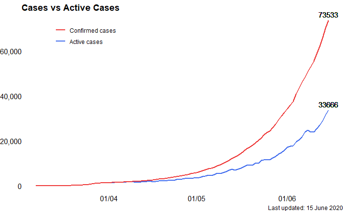

```r
  visualConfirmedVsActive # Graph
```

## 2. Total Deaths

The data for this graph was sourced from the [Data Science for Social Impact Research Group](https://github.com/dsfsi/covid19za).

```r
# Data transformaiton
  dataProvincialConfirmed2 <- rawProvincialConfirmed %>%
    select(date, total) %>%
    mutate(date = as.Date(date, format = "%d-%m-%Y")) %>%
    rename(cumulative_confirmed = total)

  dataProvincialDeaths2 <- rawProvincialDeaths %>%
    select(date, total) %>%
    mutate(date = as.Date(date, format = "%d-%m-%Y")) %>%
    rename(cumulative_deaths = total)

  dataFatalityRate <- dataProvincialConfirmed2 %>%
    left_join(dataProvincialDeaths2, by = "date") %>%
    fill(cumulative_deaths) %>%
    replace_na(list(cumulative_deaths = 0)) %>%
    mutate(fatality_rate = (cumulative_deaths/cumulative_confirmed)*100)

  write_csv(dataFatalityRate, path = "~/assignment1/data_out/fatalityRate.csv")

# Data visualisation
## Creating the date caption for the visualisation
    captionTotalDeaths <- dataFatalityRate %>%
      select(date, everything()) %>%
      filter(date == max(date)) %>%
      head(1) %>%
      mutate(date = as.character(date, format("%d %B %Y")))

    captionTotalDeaths <- paste("Last updated: ", captionTotalDeaths)

## Creating the graph
  visualTotalDeaths <- dataFatalityRate %>%
    ggplot(aes(x = date)) +
    geom_line(aes(y = fatality_rate * 100), colour = "grey60", size = 1, linetype = "dashed") +
    geom_line(aes(y = cumulative_deaths), colour = "brown2", size = 1) +
    geom_text(aes(x = max(date), y = max(cumulative_deaths), label = max(cumulative_deaths), vjust = -.5)) +
    geom_text(aes(x = as.Date("2020-03-25"), y = 250, label = "Case fatality rate (%)")) +
    labs(title = "Total Deaths", caption = captionTotalDeaths) +
    scale_x_date(breaks = date_breaks("1 month"), labels = date_format("%d/%m")) +
    scale_y_continuous(breaks = seq(0, 2200, 200), labels = comma, sec.axis = sec_axis(~ . / 20000, name = "Case fatality rate (%)", seq(0, 100, 0.01), labels = percent_format(accuracy = 1))) +
    theme_void() +
    theme(plot.title = element_text(face = "bold"), plot.caption = element_text(hjust = 1.04), axis.text.x = element_text(), axis.text.y = element_text(hjust = 1))

  ggsave(visualTotalDeaths, filename = "totalDeaths.png", path ="~/assignment1/images/", width = 40, height = 20, units = "cm")

# Output
  dataFatalityRate # Data
```

| date | cumulative_confirmed | cumulative_deaths | fatality_rate |
| --- | --- | --- | --- |
| 2020-03-05 | 1 | 0 | 0.00000000 |
| 2020-03-07 | 2 | 0 | 0.00000000 |
| 2020-03-08 | 3 | 0 | 0.00000000 |
| 2020-03-09 | 7 | 0 | 0.00000000 |
| 2020-03-11 | 13 | 0 | 0.00000000 |
| 2020-03-12 | 16 | 0 | 0.00000000 |
| 2020-03-13 | 24 | 0 | 0.00000000 |
| 2020-03-14 | 38 | 0 | 0.00000000 |
| 2020-03-15 | 51 | 0 | 0.00000000 |
| 2020-03-16 | 62 | 0 | 0.00000000 |

[output cut: 91 more lines]

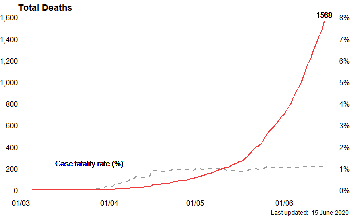

```r
  visualTotalDeaths # Graph
```

## 3. Deaths by Gender

The data for this graph was sourced from the [Data Science for Social Impact Research Group](https://github.com/dsfsi/covid19za).

```r
# Data transformation
  dataGenderDeaths <- rawDeathStats %>%
    select(date, gender_male, gender_female, gender_unknown) %>%
    pivot_longer(c("gender_male", "gender_female", "gender_unknown"), names_to = "gender", values_to = "deaths") %>%
    mutate(date = as.Date(date, format = "%d-%m-%Y"), gender = factor(gender, levels = c("gender_male", "gender_female", "gender_unknown"), labels = c("male", "female", "unk"))) %>%
    filter(date == max(date))

  write_csv(dataGenderDeaths, path = "~/assignment1/data_out/genderDeaths.csv")

# Data visualisation
## Creating the date caption for the visualisation
  captionGenderDeaths <- dataGenderDeaths %>%
    select(date, everything()) %>%
    filter(date == max(date)) %>%
    head(1) %>%
    mutate(date = as.character(date, format("%d %B %Y")))

  captionGenderDeaths <- paste("Last updated: ", captionGenderDeaths)

## Creating the graph
  visualGenderDeaths <- dataGenderDeaths %>%
    ggplot(aes(x = gender, y = deaths)) +
    geom_col(stat = "count", fill = "brown2") +
    labs(title = "Deaths by Gender", caption = captionGenderDeaths) +
    geom_text(aes(x = gender, y = deaths, label = deaths), vjust = -0.5) +
    theme_void() +
    theme(plot.title = element_text(face = "bold"), plot.caption = element_text(hjust = 1), axis.text.x = element_text())

  ggsave(visualGenderDeaths, filename = "genderDeaths.png", path ="~/assignment1/images/", width = 40, height = 20, units = "cm")

# Output
  dataGenderDeaths # Data
```

| date | gender | deaths |
| --- | --- | --- |
| 2020-06-13 | male | 728 |
| 2020-06-13 | female | 693 |
| 2020-06-13 | unk | 2 |

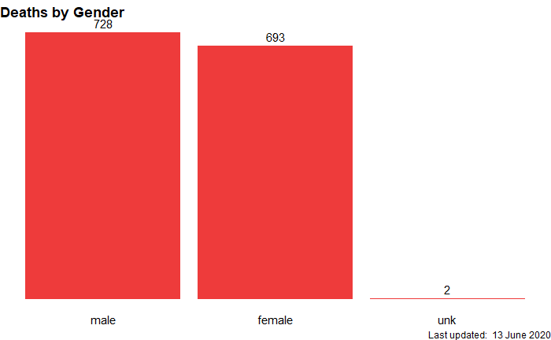

```r
  visualGenderDeaths # Graph
```

## 4. Deaths by Age

The data for this graph was sourced from the [Data Science for Social Impact Research Group](https://github.com/dsfsi/covid19za).

```r
# Data transformation
  dataAgeDeaths <- rawDeathStats %>%
    select(date, `age_0-9`, `age_10-19`, `age_20-29`, `age_30-39`, `age_40-49`, `age_50-59`, `age_60-69`, `age_70-79`, `age_80-89`, `age_90-99`, age_unknown) %>%
    pivot_longer(c("age_0-9", "age_10-19", "age_20-29", "age_30-39", "age_40-49", "age_50-59", "age_60-69", "age_70-79", "age_80-89", "age_90-99", "age_unknown"), names_to = "age_gap", values_to = "deaths") %>%
    mutate(date = as.Date(date, format = "%d-%m-%Y"),
           age_gap = fct_recode(age_gap,
              "0-9" = "age_0-9",
              "10-19" = "age_10-19",
              "20-29" = "age_20-29",
              "30-39" = "age_30-39",
              "40-49" = "age_40-49",
              "50-59" = "age_50-59",
              "60-69" = "age_60-69",
              "70-79" = "age_70-79",
              "80+" = "age_80-89",
              "80+" = "age_90-99",
              "unk" = "age_unknown")) %>%
    filter(date == max(date)) %>%
    group_by(date, age_gap) %>%
    summarise_all(sum)

  write_csv(dataAgeDeaths, path = "~/assignment1/data_out/ageDeaths.csv")

# Data visualisation
## Creating the date caption for the visualisation
  captionAgeDeaths <- dataAgeDeaths %>%
    select(date, everything()) %>%
    filter(date == max(date)) %>%
    head(1) %>%
    mutate(date = as.character(date, format("%d %B %Y")))

  captionAgeDeaths <- paste("Last updated: ", captionAgeDeaths)

## Creating the graph
  visualAgeDeaths <- dataAgeDeaths %>%
    ggplot(aes(age_gap, deaths)) +
    geom_bar(stat = "identity", fill = "brown2") +
    geom_text(aes(age_gap, deaths, label = deaths), vjust = -0.5) +
    labs(title = "Deaths by Age", caption = captionAgeDeaths) +
    theme_void() +
    theme(plot.title = element_text(face = "bold"), plot.caption = element_text(hjust = 1), axis.text.x = element_text())

  ggsave(visualAgeDeaths, filename = "ageDeaths.png", path ="~/assignment1/images/", width = 40, height = 20, units = "cm")

# Output
  dataAgeDeaths # Data
```

| date | age_gap | deaths |
| --- | --- | --- |
| 2020-06-13 | 0-9 | 3 |
| 2020-06-13 | 10-19 | 4 |
| 2020-06-13 | 20-29 | 21 |
| 2020-06-13 | 30-39 | 85 |
| 2020-06-13 | 40-49 | 179 |
| 2020-06-13 | 50-59 | 346 |
| 2020-06-13 | 60-69 | 387 |
| 2020-06-13 | 70-79 | 249 |
| 2020-06-13 | 80+ | 141 |
| 2020-06-13 | unk | 8 |

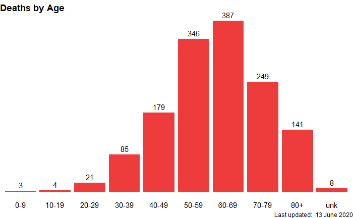

```r
  visualAgeDeaths # Graph
```

## 5. Deaths by Province

The data for this graph was sourced from the [Data Science for Social Impact Research Group](https://github.com/dsfsi/covid19za).

```r
# Data transformation
  dataDeathsByProvince <- rawProvincialDeaths %>%
    select(date, EC:WC) %>%
    pivot_longer(c("EC", "FS", "GP", "KZN", "LP", "MP", "NC", "NW", "WC"), names_to = "province", values_to = "deaths") %>%
    mutate(date = as.Date(date, format = "%d-%m-%Y")) %>%
    mutate(province = factor(province)) %>%
    filter(date == max(date)) %>%
    arrange(desc(deaths))

  write_csv(dataDeathsByProvince, path = "~/assignment1/data_out/deathsByProv.csv")

# Data visualisation
## Creating the date caption for the visualisation
  captionProvDeaths <- dataDeathsByProvince %>%
    select(date, everything()) %>%
    filter(date == max(date)) %>%
    head(1) %>%
    mutate(date = as.character(date, format("%d %B %Y")))

  captionProvDeaths <- paste("Last updated:", captionProvDeaths)

## Creating the graph
  visualDeathsByProvince <- dataDeathsByProvince %>%
    ggplot(aes(x = fct_inorder(province), y = deaths)) +
    geom_col(stat = "identity", fill = "brown2") +
    geom_text(aes(label = deaths), vjust = -0.5) +
    labs(title = "Deaths by Province", caption = captionProvDeaths) +
    theme_void() +
    theme(plot.title = element_text(face = "bold"), axis.text.x = element_text())

  ggsave(visualDeathsByProvince, filename = "deathsByProvince.png", path ="~/assignment1/images/", width = 40, height = 20, units = "cm")

# Output
  dataDeathsByProvince # Data
```

| date | province | deaths |
| --- | --- | --- |
| 2020-06-15 | WC | 1156 |
| 2020-06-15 | EC | 236 |
| 2020-06-15 | GP | 87 |
| 2020-06-15 | KZN | 69 |
| 2020-06-15 | FS | 9 |
| 2020-06-15 | NW | 5 |
| 2020-06-15 | LP | 4 |
| 2020-06-15 | MP | 1 |
| 2020-06-15 | NC | 1 |

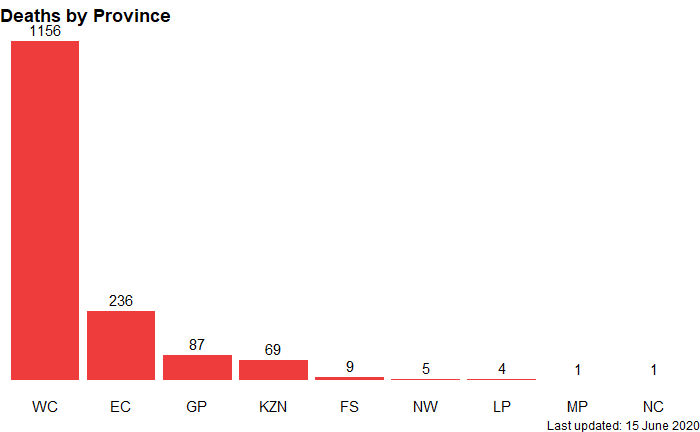

```r
  visualDeathsByProvince # Graph
```

## 6. Deaths by Province (per 100k)

The data for this graph was sourced from the [Data Science for Social Impact Research Group](https://github.com/dsfsi/covid19za).

```r
# Data transformation
  dataProvincialPopulation6 <- rawProvinicialPopulation %>%
    rename(c("province" = X1, "population" = X2)) %>%
    mutate(province = factor(province)) %>%
    mutate(province = fct_recode(province, "GP" = "Gauteng",
                                           "KZN" = "KwaZulu-Natal",
                                           "WC" = "Western Cape",
                                           "EC" = "Eastern Cape",
                                           "LP" = "Limpopo",
                                           "MP" = "Mpumalanga",
                                           "NW" = "Northwest",
                                           "FS" = "Free State",
                                           "NC" = "Northern Cape"))

  dataProvincialDeathsPer100k <- dataDeathsByProvince %>%
    left_join(dataProvincialPopulation6, by = "province") %>%
    mutate(deaths_per_100k = round((deaths / population) * 100000, 2)) %>%
    arrange(desc(deaths_per_100k))

  write_csv(dataProvincialDeathsPer100k, path = "~/assignment1/data_out/provincialDeathsPer100k.csv")

# Data visualisation
## Creating the date caption for the visualisation
  captionProvDeaths <- dataProvincialDeathsPer100k %>%
    select(date, everything()) %>%
    filter(date == max(date)) %>%
    head(1) %>%
    mutate(date = as.character(date, format("%d %B %Y")))

  captionProvDeaths <- paste("Last updated:", captionProvDeaths)

## Creating the graph
  visualDeathsByProvince100k <- dataProvincialDeathsPer100k %>%
    ggplot(aes(x = fct_inorder(province), y = deaths_per_100k)) +
    geom_col(fill = "brown2") +
    geom_text(aes(label = deaths_per_100k), vjust = -0.5) +
    labs(title = "Deaths by Province (per 100k)", caption = captionProvDeaths) +
    theme_void() +
    theme(plot.title = element_text(face = "bold"), axis.text.x = element_text())

  ggsave(visualDeathsByProvince100k, filename = "provincialDeaths100k.png", path ="~/assignment1/images/", width = 40, height = 20, units = "cm")

# Output
  dataProvincialDeathsPer100k # Data
```

| date | province | deaths | population | deaths_per_100k |
| --- | --- | --- | --- | --- |
| 2020-06-15 | WC | 1156 | 6844272 | 16.89 |
| 2020-06-15 | EC | 236 | 6712276 | 3.52 |
| 2020-06-15 | KZN | 69 | 11289086 | 0.61 |
| 2020-06-15 | GP | 87 | 15176115 | 0.57 |
| 2020-06-15 | FS | 9 | 2887465 | 0.31 |
| 2020-06-15 | NW | 5 | 4027160 | 0.12 |
| 2020-06-15 | NC | 1 | 1263875 | 0.08 |
| 2020-06-15 | LP | 4 | 5982584 | 0.07 |
| 2020-06-15 | MP | 1 | 4592187 | 0.02 |

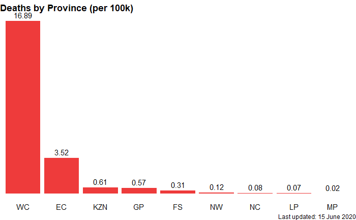

```r
  visualDeathsByProvince100k # Graph
```

## 7. Deaths by Age (per 100k)

The data for this graph was sourced from the [Data Science for Social Impact Research Group](https://github.com/dsfsi/covid19za) via StatsSA.

```r
# Data transformation
  dataPopulationAge <- rawPopulationAge %>%
    fill(Province) %>%
    filter(Province == "All Provinces") %>%
    rename(c("age_gap" = "Age", "population" = "Total")) %>%
    select(age_gap, population) %>%
    mutate(age_gap = as.factor(age_gap)) %>%
    mutate(age_gap = fct_collapse(age_gap,
              "0-9" = c("0–4", "5–9"),
              "10-19" = c("10–14", "15–19"),
              "20-29" = c("20–24", "25–29"),
              "30-39" = c("30–34", "35–39"),
              "40-49" = c("40–44", "45–49"),
              "50-59" = c("50–54", "55–59"),
              "60-69" = c("60–64", "65–69"),
              "70-79" = c("70–74", "75–79"),
              other_level = "80+")) %>%
    group_by(age_gap = tolower(age_gap)) %>%
    summarise_each(sum)

  dataAgeDeathsPer100k <- dataAgeDeaths %>%
    left_join(dataPopulationAge, by = "age_gap") %>%
    mutate(age_gap = as.factor(age_gap)) %>%
    drop_na() %>%
    select(age_gap, deaths, population) %>%
    mutate(death_per_100k = round((deaths / population) * 100000, 2))

  write_csv(dataAgeDeathsPer100k, path = "~/assignment1/data_out/ageDeathsPer100k.csv")

# Data visualisation
## Creating the date caption for the visualisation
  captionAgeDeathsPer100k <- dataAgeDeathsPer100k %>%
    select(date, everything()) %>%
    filter(date == max(date)) %>%
    head(1) %>%
    mutate(date = as.character(date, format("%d %B %Y")))

  captionAgeDeathsPer100k <- paste("Last updated: ", captionAgeDeathsPer100k)

## Creating the graph
  visualAgeDeathsPer100k <- dataAgeDeathsPer100k %>%
    ggplot(aes(x = age_gap, y = death_per_100k)) +
    geom_bar(stat = "identity", fill = "brown2") +
    geom_text(aes(age_gap, death_per_100k, label = death_per_100k), vjust = -0.5) +
    labs(title = "Deaths by Age (per 100k)", caption = captionAgeDeathsPer100k) +
    theme_void() +
    theme(plot.title = element_text(face = "bold"), plot.caption = element_text(hjust = 1), axis.text.x = element_text())

  ggsave(visualAgeDeathsPer100k, filename = "ageDeathsPer100k.png", path ="~/assignment1/images/", width = 40, height = 20, units = "cm")

# Output
  dataAgeDeathsPer100k # Data
```

| date | age_gap | deaths | population | death_per_100k |
| --- | --- | --- | --- | --- |
| 2020-06-13 | 0-9 | 3 | 11471385 | 0.03 |
| 2020-06-13 | 10-19 | 4 | 10087904 | 0.04 |
| 2020-06-13 | 20-29 | 21 | 10442757 | 0.20 |
| 2020-06-13 | 30-39 | 85 | 10109138 | 0.84 |
| 2020-06-13 | 40-49 | 179 | 6631025 | 2.70 |
| 2020-06-13 | 50-59 | 346 | 4727560 | 7.32 |
| 2020-06-13 | 60-69 | 387 | 3154597 | 12.27 |
| 2020-06-13 | 70-79 | 249 | 1547686 | 16.09 |
| 2020-06-13 | 80+ | 141 | 602969 | 23.38 |

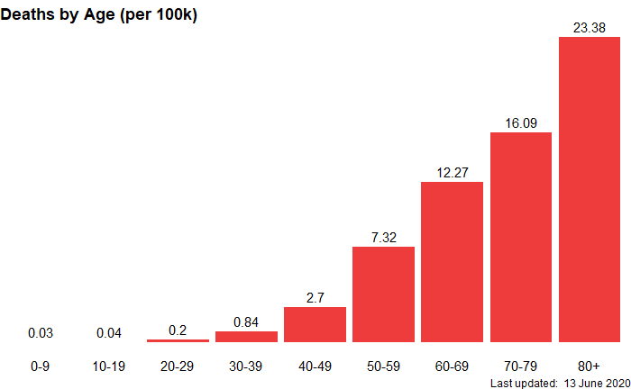

```r
  visualAgeDeathsPer100k # Graph
```

## 8. Confirmed and Active Cases by Province

The data for this graph was sourced from the [Data Science for Social Impact Research Group](https://github.com/dsfsi/covid19za). For the graph, we opted to keep the y-axes visible due to ggplot cutting off the numbers that label the lines.

```r
# Data transformation
  dataProvincialConfirmed8 <- rawProvincialConfirmed %>%
    select(date, EC:WC) %>%
    pivot_longer(c("EC", "FS", "GP", "KZN", "LP", "MP", "NC", "NW", "WC"), names_to = "province", values_to = "confirmed")

  dataProvincialRecoveries <- rawProvincialRecoveries %>%
    select(date, EC:WC) %>%
    pivot_longer(c("EC", "FS", "GP", "KZN", "LP", "MP", "NC", "NW", "WC"), names_to = "province", values_to = "recoveries")

  dataConfirmedVsActiveProvince <- dataProvincialConfirmed8 %>%
    left_join(dataProvincialRecoveries, by = c("date", "province")) %>%
    mutate(active = confirmed - recoveries) %>%
    mutate(date = as.Date(date, format = "%d-%m-%Y")) %>%
    mutate(province = factor(province, levels = c("GP", "WC", "KZN", "EC", "NC", "FS", "LP", "NW", "MP"), labels = c("GAUTENG", "WESTERN CAPE", "KWAZULU NATAL", "EASTERN CAPE", "NORTHERN CAPE", "FREE STATE", "LIMPOPO", "NORTH WEST", "MPUMALANGA"))) %>%
    drop_na() %>%
    group_by(province) %>%
    arrange(desc(confirmed))

  write_csv(dataConfirmedVsActiveProvince, path = "~/assignment1/data_out/confirmedVsActiveProvincial.csv")

# Data visualisation
## Creating the date caption for the visualisation
  captionProvConfirmedActive <- dataConfirmedVsActiveProvince %>%
    select(date, everything()) %>%
    filter(date == max(date)) %>%
    head(1) %>%
    mutate(date = as.character(date, format("%d %B %Y")))

  captionProvConfirmedActive <- paste("Last updated:", captionProvConfirmedActive)

## Creating the labels for the visualisation
  labelConfirmed <- dataConfirmedVsActiveProvince %>%
    group_by(province) %>%
    filter(date == max(date)) %>%
    select(confirmed)

  labelActive <- dataConfirmedVsActiveProvince %>%
    group_by(province) %>%
    filter(date == max(date)) %>%
    select(active)

## Creating the graph
  visualProvConfirmedVsActive <- dataConfirmedVsActiveProvince %>%
    ggplot(aes(x = date, y = confirmed, group = fct_inorder(province))) +
    geom_line(aes(colour = "Confirmed cases")) +
    geom_line(aes(y = active, colour = "Active cases")) +
    geom_text(data = dataConfirmedVsActiveProvince %>% group_by(province) %>% top_n(1, active), aes(x = max(date), y = max(active), label = active)) +
    geom_text(data = dataConfirmedVsActiveProvince %>% group_by(province) %>% top_n(1, confirmed),aes(x = max(date), y = max(confirmed), label = confirmed)) +
    scale_x_date(breaks = date_breaks("1 months"), labels = date_format("%d/%m")) +
    scale_y_continuous(breaks = seq(0, 45000, 19000), labels = comma) +
    scale_colour_manual("", values = c("brown2", "royalblue2"), breaks = c("Confirmed cases", "Active cases")) +
    labs(title = "Confirmed and Active Cases by Province", caption = captionProvConfirmedActive) +
    facet_wrap(~fct_inorder(province)) +
    theme_void() +
    theme(plot.title = element_text(face = "bold"), axis.text.x = element_text(), axis.text.y = element_text())

  ggsave(visualProvConfirmedVsActive, filename = "provinciaConfirmedVsActive.png", path ="~/assignment1/images/", width = 40, height = 20, units = "cm")

# Ouput
  dataConfirmedVsActiveProvince # Data
```

| date | province | confirmed | recoveries | active |
| --- | --- | --- | --- | --- |
| 2020-06-15 | WESTERN CAPE | 44143 | 28615 | 15528 |
| 2020-06-14 | WESTERN CAPE | 42539 | 27527 | 15012 |
| 2020-06-13 | WESTERN CAPE | 40605 | 26736 | 13869 |
| 2020-06-12 | WESTERN CAPE | 38926 | 25435 | 13491 |
| 2020-06-11 | WESTERN CAPE | 37422 | 22862 | 14560 |
| 2020-06-10 | WESTERN CAPE | 36021 | 22862 | 13159 |
| 2020-06-09 | WESTERN CAPE | 34819 | 20791 | 14028 |
| 2020-06-08 | WESTERN CAPE | 33568 | 19101 | 14467 |
| 2020-06-07 | WESTERN CAPE | 31824 | 17366 | 14458 |
| 2020-06-06 | WESTERN CAPE | 30379 | 17355 | 13024 |

[output cut: 476 more lines]

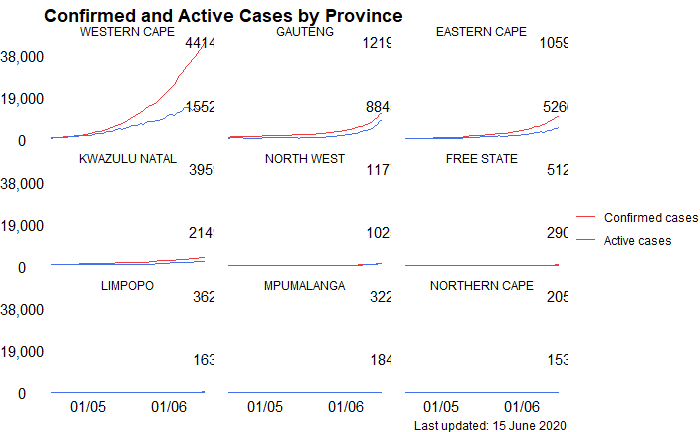

```r
  visualProvConfirmedVsActive # Graph
```

## 9. Provincial Infecions per 100,000 Population

The data for this graph was sourced from the [Data Science for Social Impact Research Group](https://github.com/dsfsi/covid19za).

```r
# Data transformation
  dataProvincialInfections <- rawProvincialConfirmed %>%
    select(date, EC:WC) %>%
    pivot_longer(c("EC", "FS", "GP", "KZN", "LP", "MP", "NC", "NW", "WC"), names_to = "province", values_to = "total_infections") %>%
    mutate(date = as.Date(date, format = "%d-%m-%Y"),
           province = fct_recode(province,
                                 "Eastern Cape" = "EC",
                                 "Free State" = "FS",
                                 "Gauteng" = "GP",
                                 "KwaZulu Natal" = "KZN",
                                 "Limpopo" = "LP",
                                 "Mpumalanga" = "MP",
                                 "Northern Cape" = "NC",
                                 "North West" = "NW",
                                 "Western Cape" = "WC")) %>%
    filter(date == max(date))

  dataProvincialPopulation <- rawProvinicialPopulation %>%
    rename(province = X1, population = X2) %>%
    mutate(province = fct_recode(province,
                                 "KwaZulu Natal" = "KwaZulu-Natal",
                                 "North West" = "Northwest"))

  dataProvincialInfectionsPopulation <- dataProvincialInfections %>%
    inner_join(dataProvincialPopulation,  by = "province") %>%
    mutate(infections_per_100k = round((total_infections * 100000) / population, 2)) %>%
    arrange(desc(infections_per_100k))

  write_csv(dataProvincialInfectionsPopulation, path = "~/assignment1/data_out/provincialInfectionsPopulation.csv")

# Data visualisation
## Creating the date caption for the visualisation
  captionProvincialInfections <- dataProvincialInfections %>%
    select(date, everything()) %>%
    filter(date == max(date)) %>%
    head(1) %>%
    mutate(date = as.character(date, format("%d %B %Y")))

  captionProvincialInfections <- paste("Last updated: ", captionProvincialInfections)

## Creating the graph
  visualProvincialInfections <- dataProvincialInfectionsPopulation %>%
    ggplot(aes(fct_rev(fct_inorder(province)), infections_per_100k)) +
    geom_col(stat = "identity", fill = "brown2") +
    geom_text(aes(province, infections_per_100k, label = infections_per_100k), hjust = -0.2) +
    labs(title = "Provincial Infections per 100,000 Population", caption = captionProvincialInfections) +
    theme_void() +
    theme(plot.title = element_text(face = "bold", hjust = -0.45), plot.caption = element_text(hjust = 1), plot.margin = margin(0,0,0,3), axis.text.y = element_text(hjust = 1)) +
    coord_flip()

  ggsave(visualProvincialInfections, filename = "provincialInfections.png", path ="~/assignment1/images/", width = 40, height = 20, units = "cm")

# Ouput
  dataProvincialInfectionsPopulation # Data
```

| date | province | total_infections | population | infections_per_100k |
| --- | --- | --- | --- | --- |
| 2020-06-15 | Western Cape | 44143 | 6844272 | 644.96 |
| 2020-06-15 | Eastern Cape | 10597 | 6712276 | 157.87 |
| 2020-06-15 | Gauteng | 12193 | 15176115 | 80.34 |
| 2020-06-15 | KwaZulu Natal | 3959 | 11289086 | 35.07 |
| 2020-06-15 | North West | 1177 | 4027160 | 29.23 |
| 2020-06-15 | Free State | 512 | 2887465 | 17.73 |
| 2020-06-15 | Northern Cape | 205 | 1263875 | 16.22 |
| 2020-06-15 | Mpumalanga | 322 | 4592187 | 7.01 |
| 2020-06-15 | Limpopo | 362 | 5982584 | 6.05 |

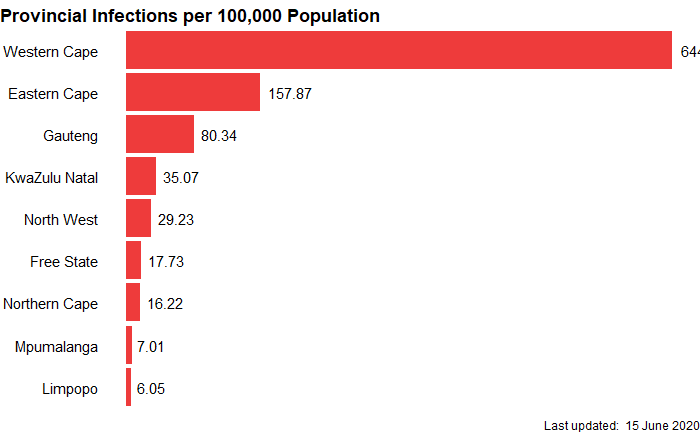

```r
  visualProvincialInfections # Graph
```

## 10. Average Daily Tests per Week

The data for this graph was sourced from the [Data Science for Social Impact Research Group](https://github.com/dsfsi/covid19za).

```r
# Data transformation
  options(lubridate.week.start = 5)

  dataAvgTestsPerWeek <- rawTesting %>%
    select(date, cumulative_tests) %>%
    mutate(date = as.Date(date, format = "%d-%m-%Y")) %>%
    complete(date = seq.Date(min(date), max(date), by = "day")) %>%
    fill(cumulative_tests) %>%
    subset(date >= "2020-03-06") %>%
    mutate(test_increases = cumulative_tests - lag(cumulative_tests)) %>%
    drop_na() %>%
    mutate(week_start = floor_date(date, unit = "week")) %>%
    group_by(week_start) %>%
    summarise(week_end = max(date), avg_week_test_increases = mean(test_increases))

  write_csv(dataAvgTestsPerWeek, path = "~/assignment1/data_out/avgTestsPerWeek.csv")

# Data visualisation
## Creating the date caption for the visualisation
  captionAvgTestsWeek <- dataProvincialDeathsPer100k %>%
    select(date, everything()) %>%
    filter(date == max(date)) %>%
    head(1) %>%
    mutate(date = as.character(date, format("%d %B %Y")))

  captionAvgTestsWeek <- paste("Last updated:", captionAvgTestsWeek)

## Creating the graph
  visualAvgTestsPerWeek <- dataAvgTestsPerWeek %>%
    ggplot(aes(x = week_start, y = round(avg_week_test_increases))) +
    geom_col(stat = "identity", fill = "brown2") +
    geom_text(aes(x = week_start, y = round(avg_week_test_increases), label = round(avg_week_test_increases)), hjust = -0.2) +
    scale_x_date(breaks = date_breaks("1 week"), labels = date_format("%d %b"), expand = c(0,1)) +
    labs(title = "Average Daily Tests per Week", caption = captionAvgTestsWeek) +
    theme_void() +
    theme(plot.title = element_text(face = "bold"), plot.caption = element_text(hjust = 1), plot.margin = margin(0,0,0,3), axis.text.y = element_text(hjust = 1)) +
    coord_flip()

  ggsave(visualAvgTestsPerWeek, filename = "avgTestsPerWeek.png", path ="~/assignment1/images/", width = 30, height = 20, units = "cm")

# Output
  dataAvgTestsPerWeek # Data
```

| week_start | week_end | avg_week_test_increases |
| --- | --- | --- |
| 2020-03-06 | 2020-03-12 | 108.0000 |
| 2020-03-13 | 2020-03-19 | 569.1429 |
| 2020-03-20 | 2020-03-26 | 2234.1429 |
| 2020-03-27 | 2020-04-02 | 3927.7143 |
| 2020-04-03 | 2020-04-09 | 2987.0000 |
| 2020-04-10 | 2020-04-16 | 3740.8571 |
| 2020-04-17 | 2020-04-23 | 6930.0000 |
| 2020-04-24 | 2020-04-30 | 9137.1429 |
| 2020-05-01 | 2020-05-07 | 12089.0000 |
| 2020-05-08 | 2020-05-14 | 15837.8571 |

[output cut: 5 more lines]

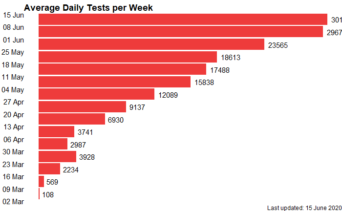

```r
  visualAvgTestsPerWeek # Graph
```

## 11. Average Daily Positives per Week

The data for this graph was sourced from the [Data Science for Social Impact Research Group](https://github.com/dsfsi/covid19za).

```r
# Data transformation
  options(lubridate.week.start = 5)

  dataAvgDailyPositives <- rawProvincialConfirmed %>%
      select(date, total) %>%
      mutate(date = as.Date(date, format = "%d-%m-%Y")) %>%
      mutate(total_lagged = lag(total)) %>%
      na.omit() %>%
      mutate(daily_increase = total - total_lagged) %>%
      subset(date >= "2020-03-06") %>%
      mutate(week_start = floor_date(date, unit = "week")) %>%
      group_by(week_start) %>%
      summarise(week_end = max(date), avg_daily_positives = mean(daily_increase))

  write_csv(dataAvgTestsPerWeek, path = "~/assignment1/data_out/avgDailyPositives.csv")

# Data visualisation
## Creating the date caption for the visualisation
  captionAvgDailyPositives <- rawProvincialConfirmed %>%
    select(date, everything()) %>%
    mutate(date = as.Date(date, format = "%d-%m-%Y")) %>%
    filter(date == max(date)) %>%
    head(1) %>%
    mutate(date = as.character(date, format("%d %B %Y")))

  captionAvgDailyPositives <- paste("Last updated:", captionAvgDailyPositives)

## Creating the graph
  visualAvgDailyPositives <- dataAvgDailyPositives %>%
    ggplot(aes(x = week_start, y = round(avg_daily_positives))) +
    geom_col(stat = "identity", fill = "brown2") +
    geom_text(aes(x = week_start, y = round(avg_daily_positives), label = round(avg_daily_positives)), hjust = -0.2) +
    scale_x_date(breaks = date_breaks("1 week"), labels = date_format("%d %b"), expand = c(0,1)) +
    labs(title = "Average Daily Positives per Week", caption = captionAvgDailyPositives) +
    theme_void() +
    theme(plot.title = element_text(face = "bold"), plot.caption = element_text(hjust = 1), plot.margin = margin(0,0,0,3), axis.text.y = element_text(hjust = 1)) +
    coord_flip()

  ggsave(visualAvgDailyPositives, filename = "avgDailyPositives.png", path ="~/assignment1/images/", width = 30, height = 20, units = "cm")

# Output
  dataAvgDailyPositives # Data
```

| week_start | week_end | avg_daily_positives |
| --- | --- | --- |
| 2020-03-06 | 2020-03-12 | 3.00000 |
| 2020-03-13 | 2020-03-19 | 19.14286 |
| 2020-03-20 | 2020-03-26 | 111.00000 |
| 2020-03-27 | 2020-04-02 | 76.42857 |
| 2020-04-03 | 2020-04-09 | 67.42857 |
| 2020-04-10 | 2020-04-16 | 95.85714 |
| 2020-04-17 | 2020-04-23 | 192.57143 |
| 2020-04-24 | 2020-04-30 | 242.00000 |
| 2020-05-01 | 2020-05-07 | 369.28571 |
| 2020-05-08 | 2020-05-14 | 643.85714 |

[output cut: 5 more lines]

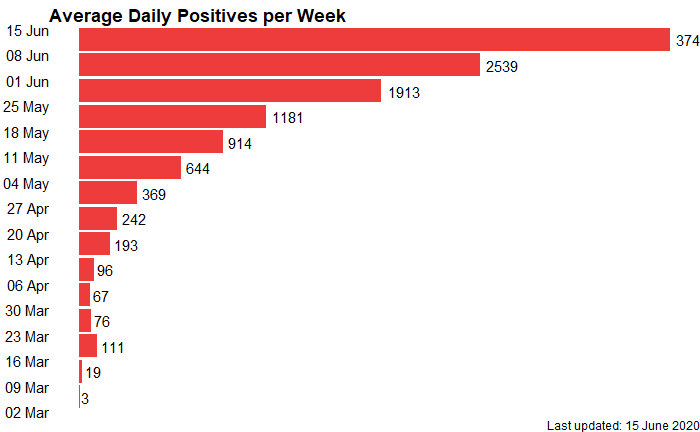

```r
  visualAvgDailyPositives # Graph
```

## 12. Number of Tests per Positive Case (weekly)

The data for this graph was sourced from the [Data Science for Social Impact Research Group](https://github.com/dsfsi/covid19za).

```r
# Data transformation
  dataTestsPerPositive <- dataAvgDailyPositives %>%
  left_join(dataAvgTestsPerWeek, by = c("week_start", "week_end")) %>%
  mutate(tests_per_positive_case = avg_week_test_increases / avg_daily_positives)

  write_csv(dataTestsPerPositive, path = "~/assignment1/data_out/testsPerPositive.csv")

# Data visualisation
## Creating the date caption for the visualisation
  captionTestsPerPositive <- rawProvincialConfirmed %>%
    select(date, everything()) %>%
    mutate(date = as.Date(date, format = "%d-%m-%Y")) %>%
    filter(date == max(date)) %>%
    head(1) %>%
    mutate(date = as.character(date, format("%d %B %Y")))

  captionTestsPerPositive <- paste("Last updated:", captionTestsPerPositive)

## Creating the graph
  visualTestsPerPositive <- dataTestsPerPositive %>%
    ggplot(aes(x = week_start, y = round(tests_per_positive_case))) +
    geom_col(stat = "identity", fill = "brown2") +
    geom_text(aes(x = week_start, y = round(tests_per_positive_case), label = round(tests_per_positive_case)), hjust = -0.2) +
    scale_x_date(breaks = date_breaks("1 week"), labels = date_format("%d %b"), expand = c(0,1)) +
    labs(title = "No. of Tests per Positive Case (weekly)", caption = captionTestsPerPositive) +
    theme_void() +
    theme(plot.title = element_text(face = "bold"), plot.caption = element_text(hjust = 1), plot.margin = margin(0,0,0,3), axis.text.y = element_text(hjust = 1)) +
    coord_flip()

  ggsave(visualTestsPerPositive, filename = "testsPerPositive.png", path ="~/assignment1/images/", width = 30, height = 20, units = "cm")

# Output
  dataTestsPerPositive # Data
```

| week_start | week_end | avg_daily_positives | avg_week_test_increases | tests_per_positive_case |
| --- | --- | --- | --- | --- |
| 2020-03-06 | 2020-03-12 | 3.00000 | 108.0000 | 36.000000 |
| 2020-03-13 | 2020-03-19 | 19.14286 | 569.1429 | 29.731343 |
| 2020-03-20 | 2020-03-26 | 111.00000 | 2234.1429 | 20.127413 |
| 2020-03-27 | 2020-04-02 | 76.42857 | 3927.7143 | 51.390654 |
| 2020-04-03 | 2020-04-09 | 67.42857 | 2987.0000 | 44.298729 |
| 2020-04-10 | 2020-04-16 | 95.85714 | 3740.8571 | 39.025335 |
| 2020-04-17 | 2020-04-23 | 192.57143 | 6930.0000 | 35.986647 |
| 2020-04-24 | 2020-04-30 | 242.00000 | 9137.1429 | 37.756789 |
| 2020-05-01 | 2020-05-07 | 369.28571 | 12089.0000 | 32.736170 |
| 2020-05-08 | 2020-05-14 | 643.85714 | 15837.8571 | 24.598402 |

[output cut: 5 more lines]

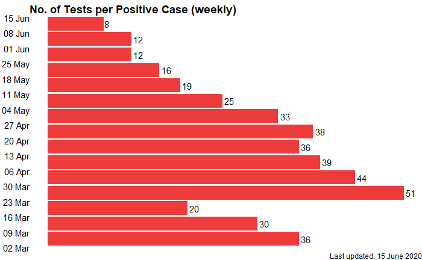

```r
  visualTestsPerPositive # Graph
```

## 13. Daily Tests and Positive Cases

The data for this graph was sourced from the [Data Science for Social Impact Research Group](https://github.com/dsfsi/covid19za).

```r
# Data transformation
  dataProvincialConfirmed13 <- rawProvincialConfirmed %>%
    select(date, total) %>%
    mutate(date = as.Date(date, format = "%d-%m-%Y")) %>%
    complete(date = seq.Date(min(date), max(date), by = "day")) %>%
    mutate(total_lagged = lag(total)) %>%
    na.omit() %>%
    mutate(daily_increase = total - total_lagged)

  dataTesting13 <- rawTesting %>%
    select(date, cumulative_tests) %>%
    mutate(date = as.Date(date, format = "%d-%m-%Y")) %>%
    complete(date = seq.Date(min(date), max(date), by = "day")) %>%
    mutate(test_increases = cumulative_tests - lag(cumulative_tests))

  dataDailyTestsVsPositiveCases <- dataProvincialConfirmed13 %>%
    left_join(dataTesting13, by = "date") %>%
    replace_na(list(cumulative_tests = 0, cum_tests_lagged = 0, test_increases = 0))

  write_csv(dataDailyTestsVsPositiveCases, path = "~/assignment1/data_out/dailyTestsVsPositiveCases.csv")

# Data visualisation
## Creating the date caption for the visualisation
    captionDailyTests <- dataDailyTestsVsPositiveCases %>%
      select(date, everything()) %>%
      filter(date == max(date)) %>%
      head(1) %>%
      mutate(date = as.character(date, format("%d %B %Y")))

    captionDailyTests <- paste("Last updated:", captionDailyTests)

## Creating the graph
  visualDailyTestsVsPositiveCases <- dataDailyTestsVsPositiveCases %>%
     ggplot(aes(x = date, y = test_increases)) +
     geom_point(aes(size = daily_increase), colour = "brown4", shape = 21, fill = "brown2", na.rm = TRUE, show.legend = FALSE) +
     geom_text(aes(x = max(date), y = max(test_increases), label = max(daily_increase))) +
     scale_radius(range = c(0.1, 20)) +
     labs(title = "Daily Tests & Positive Cases", caption = captionDailyTests) +
     scale_x_date(breaks = date_breaks("1 week"), labels = date_format("%d/%m")) +
     scale_y_continuous(labels = comma) +
     theme_void() +
     theme(plot.title = element_text(face = "bold"), axis.text.x = element_text(angle = 45), axis.text.y = element_text(), panel.grid.major.y = element_line(linetype = "dotted", colour = "grey"))

  ggsave(visualDailyTestsVsPositiveCases, filename = "dailyTestsVsPositiveCases.png", path ="~/assignment1/images/", width = 30, height = 20, units = "cm")

# Output
  dataDailyTestsVsPositiveCases # Data
```

| date | total | total_lagged | daily_increase | cumulative_tests | test_increases |
| --- | --- | --- | --- | --- | --- |
| 2020-03-08 | 3 | 2 | 1 | 0 | 0 |
| 2020-03-09 | 7 | 3 | 4 | 0 | 0 |
| 2020-03-12 | 16 | 13 | 3 | 848 | 203 |
| 2020-03-13 | 24 | 16 | 8 | 924 | 76 |
| 2020-03-14 | 38 | 24 | 14 | 1017 | 93 |
| 2020-03-15 | 51 | 38 | 13 | 1476 | 459 |
| 2020-03-16 | 62 | 51 | 11 | 2405 | 929 |
| 2020-03-17 | 85 | 62 | 23 | 2911 | 506 |
| 2020-03-18 | 116 | 85 | 31 | 3070 | 159 |
| 2020-03-19 | 150 | 116 | 34 | 4832 | 1762 |

[output cut: 88 more lines]

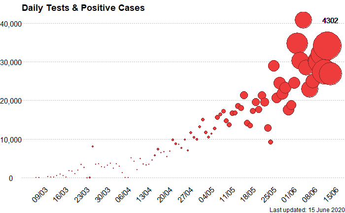

```r
  visualDailyTestsVsPositiveCases # Graph
```

## 14. Confirmed Infections (last 20 days)

The data for this graph was sourced from the [European Centre for Disease Prevention and Control](https://github.com/owid/covid-19-data/tree/master/public/data).

```r
# Data transformation
  dataConfirmedLast20Days <- rawGlobal %>%
    mutate(date = as.Date(date, format = "%Y-%m-%d")) %>%
    filter(iso_code == "ZAF") %>%
    select(date, total_cases, new_cases) %>%
    arrange(date) %>%
    tail(n = 20)

  csvConfirmedLast20Days <- write_csv(dataConfirmedLast20Days, path = "~/assignment1/data_out/confirmedLast20Days.csv")

# Data visualisation
## Creating the date caption for the visualisation
  captionConfirmedLast20Days <- dataConfirmedLast20Days %>%
    select(date, everything()) %>%
    filter(date == max(date)) %>%
    head(1) %>%
    mutate(date = as.character(date, format("%d %B %Y")))

  captionConfirmedLast20Days <- paste("Last updated:", captionConfirmedLast20Days)

## Creating the graph
  visualConfirmedInfections20Days <- csvConfirmedLast20Days %>%
    ggplot(aes(x = as.character(date, format("%d-%m-%Y")), y = new_cases)) +
    geom_col(fill = "brown2") +
    geom_text(aes(label = new_cases), hjust = -0.01) +
    labs(title = "Confirmed Infections (last 20 days)", caption = captionConfirmedLast20Days) +
    scale_x_discrete(limits = rev(csvConfirmedLast20Days$date)) +
    coord_flip() +
    theme_void() +
    theme(plot.title = element_text(face = "bold"), axis.text.y = element_text())

  ggsave(visualConfirmedInfections20Days, filename = "confirmedInfections20Days.png", path ="~/assignment1/images/", width = 30, height = 20, units = "cm")

# Output
  dataConfirmedLast20Days # Data
```

| date | total_cases | new_cases |
| --- | --- | --- |
| 2020-05-28 | 25937 | 1673 |
| 2020-05-29 | 27403 | 1466 |
| 2020-05-30 | 29240 | 1837 |
| 2020-05-31 | 30967 | 1727 |
| 2020-06-01 | 32683 | 1716 |
| 2020-06-02 | 34357 | 1674 |
| 2020-06-03 | 35812 | 1455 |
| 2020-06-04 | 37525 | 1713 |
| 2020-06-05 | 40792 | 3267 |
| 2020-06-06 | 43434 | 2642 |

[output cut: 10 more lines]

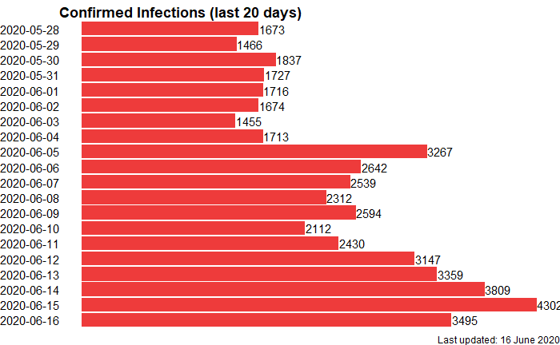

```r
  visualConfirmedInfections20Days # Graph
```

## 15. Positivity Rate: Number of Tests vs Positive Cases (%)

```r
# Data transformation
  dataProvincialConfirmed15 <- rawProvincialConfirmed %>%
    select(date, total) %>%
    mutate(date = as.Date(date, format = "%d-%m-%Y")) %>%
    mutate(case_increases = total - lag(total))

  dataTesting15 <- rawTesting %>%
    select(date, cumulative_tests) %>%
    mutate(date = as.Date(date, format = "%d-%m-%Y")) %>%
    mutate(test_increases = cumulative_tests - lag(cumulative_tests))

  dataPositivityRate <- dataProvincialConfirmed15 %>%
    left_join(dataTesting15, by = "date") %>%
    arrange(date) %>%
    mutate(positive_tests_percentage = (case_increases / test_increases) * 100) %>%
    mutate(rolling_average_7_days = rollapply(positive_tests_percentage, 7, mean, align = "right", fill = NA)) %>%
    drop_na() %>%
    tail(n = 27)

  write_csv(dataPositivityRate, path = "~/assignment1/positivityRate.csv")

#Data visualisation
## Creating the date caption for the visualisation
  captionTesting_ProvincialConfirmed <- dataPositivityRate %>%
    select(date, everything()) %>%
    filter(date == max(date)) %>%
    head(1) %>%
    mutate(date = as.character(date, format("%d %B %Y")))

  captionTesting_ProvincialConfirmed <- paste("Last updated: ", captionTesting_ProvincialConfirmed)

## Creating the graph
  visualPositivityRate <- dataPositivityRate %>%
    ggplot(aes(x = date, y = positive_tests_percentage)) +
    geom_col(aes(y = test_increases / 3333.33, fill = "TESTS CONDUCTED")) +
    geom_line(aes(fill = "POSITIVE TESTS (%)"), colour = "brown2", size = 1) +
    geom_line(aes(y = rolling_average_7_days, fill = "7-DAY ROLLING AVERAGE"), size = 1, linetype = "dashed") +
 #   geom_table_npc(tablePositivityRate, aes(npcx = 0.95, y = 0)) +
    labs(title = "Positivity Rate: Number of Tests vs Positive Cases (%)", caption = captionTesting_ProvincialConfirmed) +
    scale_x_date(breaks = date_breaks("1 week"), labels = date_format("%d/%m"), expand = c(0, 0)) +
    scale_y_continuous(breaks = seq(0, 100, 1), sec.axis = sec_axis(~ . * 3333.33 , name = "Tests Conducted", labels = comma)) +
    scale_fill_manual("", breaks = c("TESTS CONDUCTED", "POSITIVE TESTS (%)", "7-DAY ROLLING AVERAGE"), values = c("royalblue2", "brown2", "black")) +
    theme_void() +
    theme(plot.title = element_text(face = "bold"), plot.caption = element_text(hjust = 1.08), axis.text.x = element_text(), axis.text.y = element_text(), panel.grid.minor.y = element_line(linetype = "dotted", colour = "grey"))

  ggsave(visualPositivityRate, filename = "positivityRate.png", path ="~/assignment1/images/", width = 30, height = 20, units = "cm")

# Output
  dataPositivityRate # Data
```

| date | total | case_increases | cumulative_tests | test_increases | positive_tests_percentage | rolling_average_7_days |
| --- | --- | --- | --- | --- | --- | --- |
| 2020-05-20 | 18003 | 803 | 505861 | 17252 | 4.654533 | 5.009825 |
| 2020-05-21 | 19137 | 1134 | 525433 | 19572 | 5.793991 | 5.267515 |
| 2020-05-22 | 20125 | 988 | 543032 | 17599 | 5.613955 | 5.464541 |
| 2020-05-23 | 21343 | 1218 | 564370 | 21338 | 5.708126 | 5.620610 |
| 2020-05-24 | 22583 | 1240 | 583855 | 19485 | 6.363870 | 5.752244 |
| 2020-05-25 | 23615 | 1032 | 596777 | 12922 | 7.986380 | 5.969484 |
| 2020-05-26 | 24264 | 649 | 605991 | 9214 | 7.043629 | 6.166355 |
| 2020-05-27 | 25937 | 1673 | 634996 | 29005 | 5.767971 | 6.325418 |
| 2020-05-28 | 27403 | 1466 | 655723 | 20727 | 7.072900 | 6.508119 |
| 2020-05-29 | 29240 | 1837 | 680175 | 24452 | 7.512678 | 6.779365 |

[output cut: 17 more lines]

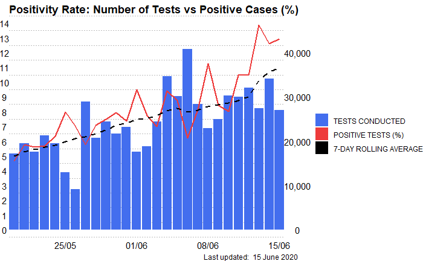

```r
  visualPositivityRate # Graph
```

## 16. Provincial Tests

The data for this graph was sourced from [Media Hack](http://mediahack.co.za/datastories/coronavirus/data-release/).

```r
# Data transformation
  dataProvincialTesting <- rawProvincialTesting %>%
    filter(date == max(date)) %>%
    select(date, province_id, total_tests) %>%
    mutate(date = as.Date(date, format = "%Y-%m-%d")) %>%
    arrange(desc(total_tests)) %>%
    mutate(province_id = factor(province_id))

  dataProvincialTesting <- dataProvincialTesting[!grepl("U", dataProvincialTesting$province_id),]

  write_csv(dataProvincialTesting, path = "~/assignment1/data_out/provincialTesting.csv")

# Data visualisation
## Creating the date caption for the visualisation
  captionProvTesting <- dataProvincialTesting %>%
    select(date, everything()) %>%
    filter(date == max(date)) %>%
    head(1) %>%
    mutate(date = as.character(date, format("%d %B %Y")))

  captionProvTesting <- paste("Last updated:", captionProvTesting)

## Creating the graph
  visualProvTesting <- dataProvincialTesting %>%
    ggplot(aes(x = province_id, y = total_tests)) +
    geom_col(fill = "brown2") +
    geom_text(aes(label = total_tests), vjust = -0.5) +
    labs(title = "Provincial Tests:", caption = captionProvTesting) +
    scale_x_discrete(limits = dataProvincialTesting$province_id) +
    theme_void() +
    theme(plot.title= element_text(face = "bold"), axis.text.x = element_text())

  ggsave(visualProvTesting, filename = "provincialTesting.png", path ="~/assignment1/images/", width = 30, height = 20, units = "cm")

# Output
  dataProvincialTesting  # Data
```

| date | province_id | total_tests |
| --- | --- | --- |
| 2020-06-11 | GP | 338211 |
| 2020-06-11 | WC | 237037 |
| 2020-06-11 | KZN | 160042 |
| 2020-06-11 | EC | 112985 |
| 2020-06-11 | FS | 60059 |
| 2020-06-11 | MP | 27127 |
| 2020-06-11 | LP | 19989 |
| 2020-06-11 | NW | 17877 |
| 2020-06-11 | NC | 8434 |

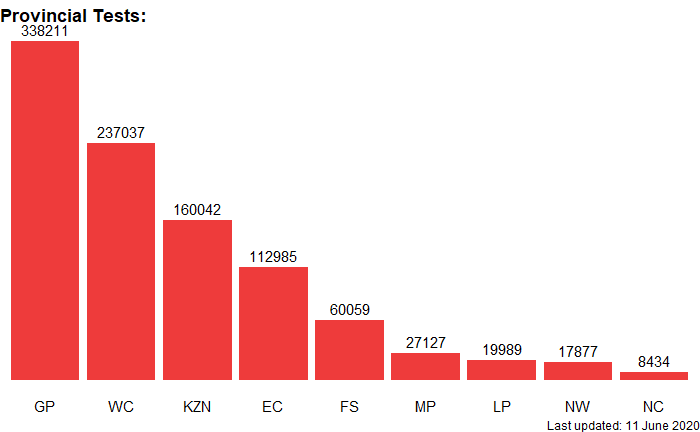

```r
  visualProvTesting # Graph
```

## 17. Provincial Tests per 100,000 Population

The data for this graph was sourced from [Media Hack](http://mediahack.co.za/datastories/coronavirus/data-release/).

```r
# Data transformation
  dataProvincialTesting100k <- rawProvincialTesting %>%
    filter(date == max(date)) %>%
    select(date, province, per_100k) %>%
    mutate(date = as.Date(date, format = "%Y-%m-%d")) %>%
    arrange(desc(per_100k)) %>%
    mutate(province = factor(province))

  dataProvincialTesting100k <- dataProvincialTesting100k[!grepl("Unknown", dataProvincialTesting100k$province),]

  write_csv(dataProvincialTesting100k, path = "~/assignment1/data_out/provincialTesting100k.csv")

# Data visualisation
## Creating the date caption for the visualisation
  captionProvTesting100k <- dataProvincialTesting100k %>%
    select(date, everything()) %>%
    filter(date == max(date)) %>%
    head(1) %>%
    mutate(date = as.character(date, format("%d %B %Y")))

  captionProvTesting100k <- paste("Last updated:", captionProvTesting100k)

# Creating the graph
  visualProvTests100k <- dataProvincialTesting100k %>%
    ggplot(aes(x = province, y = per_100k)) +
    geom_col(fill = "brown2") +
    geom_text(aes(label = per_100k), hjust = -0.1) +
    labs(title = "Provincial Tests per 100,000 Population:", caption = captionProvTesting100k) +
    scale_x_discrete(limits = rev(dataProvincialTesting100k$province)) +
    theme_void() +
    theme(plot.title = element_text(face = "bold", hjust = -0.4), plot.caption = element_text(hjust = 1), plot.margin = margin(0,0,0,3), axis.text.y = element_text(hjust = 1)) +
    coord_flip()

  ggsave(visualProvTests100k, filename = "provTests100k.png", path ="~/assignment1/images/", width = 30, height = 20, units = "cm")

# Output
  dataProvincialTesting100k # Data
```

| date | province | per_100k |
| --- | --- | --- |
| 2020-06-11 | Western Cape | 3463 |
| 2020-06-11 | Gauteng | 2229 |
| 2020-06-11 | Free State | 2080 |
| 2020-06-11 | Eastern Cape | 1683 |
| 2020-06-11 | KwaZulu Natal | 1418 |
| 2020-06-11 | Northern Cape | 667 |
| 2020-06-11 | Mpumalanga | 591 |
| 2020-06-11 | North West | 444 |
| 2020-06-11 | Limpopo | 334 |

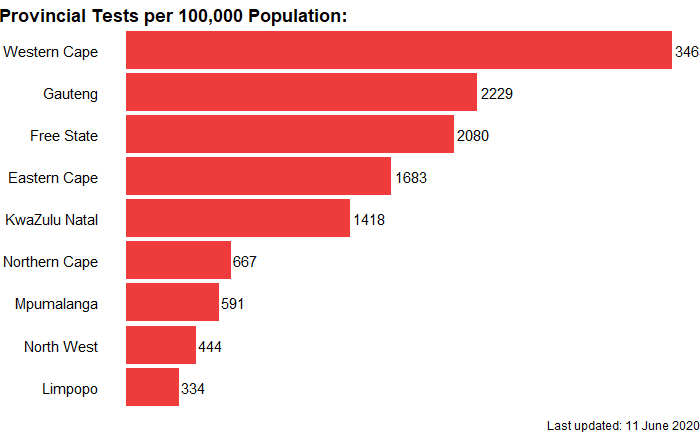

```r
  visualProvTests100k # Graph
```

## 18. Public vs Private Tests

The data for this table was scraped from the [National Institute for Communicable Diseases](https://www.nicd.ac.za/media/alerts/).

```r
# Scrape data
  alertsPage <- read_html("https://www.nicd.ac.za/media/alerts/")

  latestAlertUrls <- alertsPage %>%
  html_nodes(".elementor-post__title a:first-child") %>%
  html_attr("href")

  latestAlertPage <- read_html(latestAlertUrls[1])

  tableTestingData <- html_node(latestAlertPage, "table:nth-child(6)")

# Data transformation
  dataTestingData <- tableTestingData %>%
    html_table(fill = TRUE, header = TRUE, trim = TRUE) %>%
    select(c(1,2,4))

    write_csv(dataTestingData, path = "~/assignment1/data_out/testingData.csv")

# Data visualisation
  visualTestingData <- dataTestingData %>%
    kable(caption = "<h2><center><strong>Public vs Private Tests</strong></center><h2>", align = "c") %>%
    kable_styling(bootstrap_options = "striped", full_width = FALSE) %>%
    add_footnote("Updated daily")

  save_kable(visualTestingData, file = "testingData.png")

# Output
  dataTestingData # Data
```

| Sector | Total tested | New tested |
| --- | --- | --- |
| Private | 556 364 | 12 172 |
| Public | 592 569 | 14 803 |
| Grand Total | 1 148 933 | 26 975 |

```r
  visualTestingData # Table
```

| Sector | Total tested | New tested |
| --- | --- | --- |
| Private | 556 364 | 12 172 |
| Public | 592 569 | 14 803 |
| Grand Total | 1 148 933 | 26 975 |

<sup>a</sup> Updated daily

## 19. Case Distribution by Age

The data for this table was sourced from [Media Hack](http://mediahack.co.za/datastories/coronavirus/data-release/).

```r
# Data transformation
  dataIncidenceRisk <- rawIncidenceRisk %>%
    replace_na(list(incidence_risk_cases_per_100K = 0)) %>%
    mutate(date = as.Date(date, format = "%Y-%m-%d"), age_group = factor(age_group), incidence_risk_cases_per_100K = as.double(incidence_risk_cases_per_100K)) %>%
    filter(date == max(date)) %>%
    select(date, age_group, confirmed_cases, incidence_risk_cases_per_100K)

  write_csv(dataIncidenceRisk, path = "~/assignment1/data_out/incidenceRisk.csv")

# Data visualisation
## Format headings and columns for table
  headIncidenceRisk <- dataIncidenceRisk %>%
    select(age_group, confirmed_cases, incidence_risk_cases_per_100K) %>%
    rename(c("Age Group" = "age_group", "Total Cases" = "confirmed_cases", "Cases per 100k" = "incidence_risk_cases_per_100K")) %>%
    mutate(`Cases per 100k` = as.character(`Cases per 100k`))
    headIncidenceRisk[18,3] = " "

## Creating the date caption for the visualisation
  captionIncidenceRisk <- dataIncidenceRisk %>%
    select(date) %>%
    filter(date == max(date)) %>%
    head(1) %>%
    mutate(date = as.character(date, format("%d %B %Y")))


  captionIncidenceRisk  <- paste("Last updated:", captionIncidenceRisk )

## Create table
  visualIncdidenceRisk <- headIncidenceRisk %>%
    kable(caption = "<h2><center><strong>Case Distribution by Age</strong></center></h2>", align = "c") %>%
    kable_styling(bootstrap_options = "striped", full_width = FALSE) %>%
    add_footnote(captionIncidenceRisk)

  save_kable(visualIncdidenceRisk, file = "incidenceRisk.png")

# Output
  dataIncidenceRisk # Data
```

| date | age_group | confirmed_cases | incidence_risk_cases_per_100K |
| --- | --- | --- | --- |
| 2020-06-06 | 0-4 | 655 | 11.4 |
| 2020-06-06 | 5-9 | 591 | 10.3 |
| 2020-06-06 | 10-14 | 801 | 14.8 |
| 2020-06-06 | 15-19 | 1168 | 25.1 |
| 2020-06-06 | 20-24 | 3299 | 67.1 |
| 2020-06-06 | 25-29 | 6010 | 108.7 |
| 2020-06-06 | 30-34 | 6787 | 122.6 |
| 2020-06-06 | 35-39 | 6639 | 145.2 |
| 2020-06-06 | 40-44 | 5528 | 154.2 |
| 2020-06-06 | 45-49 | 4735 | 155.5 |

[output cut: 9 more lines]

```r
  visualIncdidenceRisk # Table
```

| Age Group | Total Cases | Cases per 100k |
| --- | --- | --- |
| 0-4 | 655 | 11.4 |
| 5-9 | 591 | 10.3 |
| 10-14 | 801 | 14.8 |
| 15-19 | 1168 | 25.1 |
| 20-24 | 3299 | 67.1 |
| 25-29 | 6010 | 108.7 |
| 30-34 | 6787 | 122.6 |
| 35-39 | 6639 | 145.2 |
| 40-44 | 5528 | 154.2 |
| 45-49 | 4735 | 155.5 |
| 50-54 | 3831 | 151.1 |
| 55-59 | 2942 | 134.2 |
| 60-64 | 1840 | 103.1 |
| 65-69 | 1202 | 87.7 |
| 70-74 | 762 | 80.2 |
| 75-79 | 520 | 87 |
| 80+ | 741 | 122.9 |
| Unknown | 234 |  |
| Total | 48285 | 82.2 |

<sup>a</sup> Last updated: 06 June 2020

## 20. Current Rt Estimates for South Africa

The data for this graph was sourced from the [Data Science for Social Impact Research Group](https://github.com/dsfsi/covid19za).

```r
# Data transformation
  dataRtEstimate <- rawRtEstimate %>%
    filter(state == "Total RSA") %>%
    select(date, ML, High_90, Low_90) %>%
    mutate(date = as.Date(date, format = "%Y-%m-%d"))

    write_csv(dataRtEstimate, path = "~/assignment1/data_out/rtEstimates.csv")

# Data visualisation
## Getting the latest Rt estimate for the graph label
  latestRt <- dataRtEstimate %>%
    filter(date == max(date))

## Creating the date caption for the visualisation
  captionRtEstimate <- dataRtEstimate %>%
    select(date, everything()) %>%
    filter(date == max(date)) %>%
    head(1) %>%
    mutate(date = as.character(date, format("%d %B %Y")))

  captionRtEstimate <- paste("Last updated:", captionRtEstimate)

## Creating the graph
  visualRtEstimate <- dataRtEstimate %>%
    ggplot(aes(date, ML)) +
    geom_line(colour = "brown2") +
    geom_point(colour = "brown2") +
    geom_ribbon(aes(x = date, ymax = High_90, ymin = Low_90, fill = "90% CREDIBLE INTERVAL"), alpha = 0.2) +
    geom_hline(aes(yintercept = 1), colour = "grey60", linetype = "dashed") +
    geom_text(data = latestRt, label = paste(format.Date(latestRt$date, "%d %B %Y"), "\nRt = ", latestRt$ML), vjust = -3, hjust = 0.9) +
    labs(title = "Current Rt Estimates for South Africa", caption = captionRtEstimate) +
    scale_x_date(breaks = date_breaks("1 week"), labels = date_format("%d/%m"), expand = c(0,1)) +
    scale_y_continuous(breaks = seq(0, 10, 0.5)) +
    scale_fill_manual("", values = "royalblue2") +
    coord_cartesian(xlim = c(date("2020-03-19"), NA), ylim = c(0,3)) +
    theme_void() +
    theme(plot.title = element_text(face = "bold"), axis.text.x = element_text(), axis.text.y = element_text(), panel.grid.major.y = element_line(linetype = "dotted", colour = "grey"), legend.position = c(0.85, 0.95))

  ggsave(visualRtEstimate, filename = "rtEstimate.png", path ="~/assignment1/images/", width = 30, height = 20, units = "cm")

# Output
  dataRtEstimate # Data
```

| date | ML | High_90 | Low_90 |
| --- | --- | --- | --- |
| 2020-03-19 | 2.11 | 3.70 | 0.22 |
| 2020-03-20 | 2.50 | 3.73 | 1.09 |
| 2020-03-21 | 2.75 | 3.71 | 1.67 |
| 2020-03-22 | 2.87 | 3.67 | 1.99 |
| 2020-03-23 | 2.97 | 3.64 | 2.20 |
| 2020-03-24 | 2.93 | 3.54 | 2.28 |
| 2020-03-25 | 2.44 | 3.00 | 1.85 |
| 2020-03-26 | 1.96 | 2.49 | 1.39 |
| 2020-03-27 | 1.34 | 1.84 | 0.74 |
| 2020-03-28 | 0.74 | 1.25 | 0.16 |

[output cut: 79 more lines]

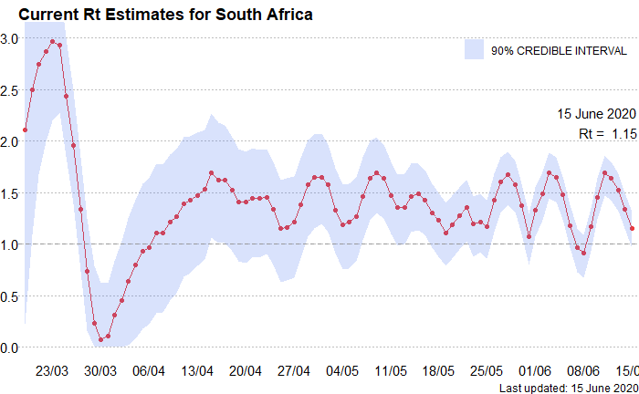

```r
  visualRtEstimate # Graph
```

## 21. Daily Infection Increases from First 100

The data for this graph was sourced from the [European Centre for Disease Prevention and Control](https://github.com/owid/covid-19-data/tree/master/public/data). We opted to use coloured lines to indicate the trajectory of daily infection increases to improve readability. ISO code legend: * BRA: Brazil * CHN: China * GBR: United Kingdom * IND: India * ITA: Italy * NZL: New zealand * RUS: Russia * SGP: Singapore * SWE: Sweden * USA: United States * ZAF: South Africa

```r
# Data transformation
  dataDailyInfections100 <- rawGlobal %>%
    filter(iso_code %in% c("BRA", "CHN", "GBR", "IND", "ITA", "NZL", "RUS", "SGP", "SWE", "USA", "ZAF") & total_cases >= 100) %>%
    select(location, date, total_cases) %>%
    fill(total_cases) %>%
    group_by(location) %>%
    mutate(date = as.Date(date, "%Y-%m-%d")) %>%
    complete(date = seq.Date(min(date), max(date), by = "day")) %>%
    mutate(day = seq(1, length(date)))

  write_csv(dataDailyInfections100, path = "~/assignment1/data_out/dailyInfections100.csv")

# Data visualisation
## Creating the date caption for the visualisation
  captionDailyInfections100 <- dataDailyInfections100 %>%
    select(date, everything()) %>%
    filter(date == max(date)) %>%
    head(1) %>%
    mutate(date = as.character(date, format("%d %B %Y")))
  captionDailyInfections100
```

| date | location | total_cases | day |
| --- | --- | --- | --- |
| 16 June 2020 | Brazil | 888271 | 94 |

```r
  captionDailyInfections100 <- paste("Last updated:", captionDailyInfections100)

## Filtering out RSA to be able to highlight it on the graph
  dataDailyInfection100ZA <- dataDailyInfections100 %>%
    filter(location == "South Africa")

## Creating the graph
  visualDailyInfection100 <- dataDailyInfections100 %>%
    filter(location != "South Africa") %>%
    ggplot() +
    geom_line(aes(day, total_cases, colour = location)) +
    geom_line(aes(day, total_cases, group = location, colour = location), size = 2, data = dataDailyInfection100ZA) +
    scale_x_continuous(breaks = seq(0, 150, by = 20), expand = c(0,0)) +
    scale_y_log10(name="Total Cases", labels = comma) +
  geom_dl(data = dataDailyInfections100, aes(day, total_cases,label = location), method =list('last.points', cex= 0.8, hjust = 0.75, vjust = -1), labels = comma) +
    labs(title = "Daily infection increases from first 100", caption = captionDailyInfections100) +
  theme(legend.position = c(0.8, 0.2),legend.text=element_text(size=15),legend.title = element_blank(),legend.background=element_blank(), legend.key=element_blank(), legend.key.size = unit(3,"line")) +
    theme_void() +
    theme(plot.title = element_text(face = "bold"), axis.text.x = element_text(), axis.text.y = element_text(hjust = 1))

  ggsave(visualDailyInfection100, filename = "dailyInfection100.png", path ="~/assignment1/images/", width = 30, height = 20, units = "cm")

# Output
  dataDailyInfections100 # Data
```

| location | date | total_cases | day |
| --- | --- | --- | --- |
| Brazil | 2020-03-15 | 121 | 1 |
| Brazil | 2020-03-16 | 200 | 2 |
| Brazil | 2020-03-17 | 234 | 3 |
| Brazil | 2020-03-18 | 291 | 4 |
| Brazil | 2020-03-19 | 428 | 5 |
| Brazil | 2020-03-20 | 621 | 6 |
| Brazil | 2020-03-21 | 904 | 7 |
| Brazil | 2020-03-22 | 1128 | 8 |
| Brazil | 2020-03-23 | 1546 | 9 |
| Brazil | 2020-03-24 | 1891 | 10 |

[output cut: 990 more lines]

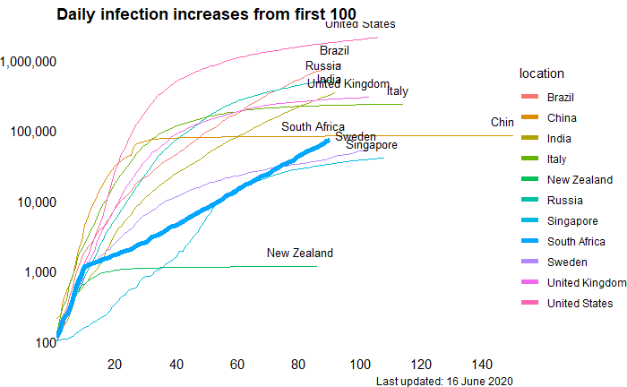

```r
  visualDailyInfection100 # Graph
```

## 22. Tests per 1 Million Population

The data for this graph was sourced from the [European Centre for Disease Prevention and Control](https://github.com/owid/covid-19-data/tree/master/public/data). * AUS: Australia * GBR: United Kingdom * ITA: Italy * NOR: Norway * USA: United States * ZAF: South Africa

```r
# Data transformation
  dataTestsPerMilGlobal <- rawGlobal %>%
    filter(iso_code %in% c("AUS", "GBR", "ITA", "NOR", "USA", "ZAF")) %>%
    select(date, location, total_tests, population) %>%
    drop_na() %>%
    group_by(location) %>%
    slice_max(date, 1) %>%
    mutate(location = factor(location), tests_per_cap = total_tests / population, tests_per_mil = round(tests_per_cap * 1000000)) %>%
    arrange(desc(tests_per_mil))

  write_csv(dataTestsPerMilGlobal, path = "~/assignment1/data_out/testsPerMilGlobal.csv")

# Data visualisation
## Creating the date caption for the visualisation
  captionTestsPerMilGlobal <- dataTestsPerMilGlobal %>%
    select(date, everything()) %>%
    filter(date == max(date)) %>%
    head(1) %>%
    mutate(date = as.character(date, format("%d %B %Y")))

  captionTestsPerMilGlobal <- paste("Last updated:", captionTestsPerMilGlobal)

## Creating the graph
  visualTestsPerMilGlobal <- dataTestsPerMilGlobal %>%
    ggplot(aes(fct_inorder(location), tests_per_mil)) +
    geom_col(fill = "brown2") +
    geom_text(aes(location, tests_per_mil, label = paste(tests_per_mil, " (", percent(tests_per_cap), ")", sep = ""), hjust = -0.1)) +
    labs(title = "Tests per 1 Million Population", caption = captionTestsPerMilGlobal) +
    theme_void() +
    theme(plot.title = element_text(face = "bold"), plot.caption = element_text(hjust = 1), plot.margin = margin(0,0,0,3), axis.text.y = element_text(hjust = 1)) +
    coord_flip()

  ggsave(visualTestsPerMilGlobal, filename = "testsPerMilGlobal.png", path ="~/assignment1/images/", width = 50, height = 20, units = "cm")

# Output
  dataTestsPerMilGlobal
```

| date | location | total_tests | population | tests_per_cap | tests_per_mil |
| --- | --- | --- | --- | --- | --- |
| 2020-06-14 | Italy | 4620718 | 60461828 | 0.07642372 | 76424 |
| 2020-06-15 | Australia | 1828149 | 25499881 | 0.07169245 | 71692 |
| 2020-06-12 | United States | 23290724 | 331002647 | 0.07036416 | 70364 |
| 2020-06-14 | United Kingdom | 3915362 | 67886004 | 0.05767554 | 57676 |
| 2020-06-15 | Norway | 285867 | 5421242 | 0.05273091 | 52731 |
| 2020-06-14 | South Africa | 1121958 | 59308690 | 0.01891726 | 18917 |

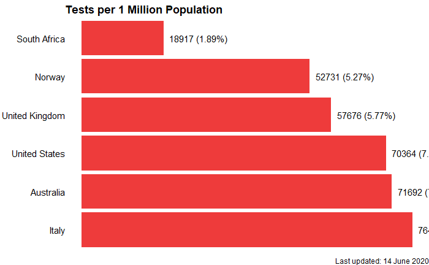

```r
  visualTestsPerMilGlobal
```

## 23. Daily Infection Increases from First 100 (Africa)

The data for this graph was sourced from the [European Centre for Disease Prevention and Control](https://github.com/owid/covid-19-data/tree/master/public/data). We opted to use coloured lines to indicate the trajectory of daily infection increases to improve readability and because the Ggplot2 canvas crops off some line labels. ISO code legend: * DZA: Algeria * EGY: Egypt * MAR: Morocco * NGA: Nigeria * ZAF: South Africa

```r
# Data transformation
  dataConfirmsPerMilAfrica <- rawGlobal %>%
    filter(iso_code %in% c("DZA", "EGY", "MAR", "NGA", "ZAF") & total_cases >= 100) %>%
    select(location, date, total_cases) %>%
    group_by(location) %>%
    mutate(date = as.Date(date)) %>%
    complete(date = seq.Date(min(date), max(date), by = "day")) %>%
    mutate(day = seq(1, length(date)))

  write_csv(dataConfirmsPerMilAfrica, path = "~/assignment1/data_out/testsPerMilAfrica.csv")

# Data visualisation
## Creating the date caption for the visualisation
  captionConfirmsPerMilAfrica <- dataConfirmsPerMilAfrica %>%
    select(date, everything()) %>%
    filter(date == max(date)) %>%
    head(1) %>%
    mutate(date = as.character(date, format("%d %B %Y")))

  captionConfirmsPerMilAfrica <- paste("Last updated:", captionConfirmsPerMilAfrica)

## Filtering out RSA to be able to highlight it on the graph
  dataConfirmsPerMilZA <- dataConfirmsPerMilAfrica %>%
    filter(location == "South Africa")

## Creating the graph
  visualConfirmsPerMilAfrica <- dataConfirmsPerMilAfrica %>%
    filter(location != "South Africa") %>%
    ggplot() +
    geom_line(aes(day, total_cases, colour = location)) +
    geom_line(aes(day, total_cases, group = location, colour = location), size = 2, data = dataConfirmsPerMilZA) +
    scale_x_continuous(breaks = seq(0, 150, by = 20), expand = c(0,0)) +
    scale_y_log10(name="Total Cases", labels = comma) +
  geom_dl(data = dataConfirmsPerMilAfrica, aes(day, total_cases,label = location), method =list('last.points', cex= 0.8, hjust = 0.75, vjust = -1), labels = comma) +
    labs(title = "Daily infection increases from first 100", caption = captionConfirmsPerMilAfrica) +
  theme(legend.position = c(0.8, 0.2),legend.text=element_text(size=15),legend.title = element_blank(),legend.background=element_blank(), legend.key=element_blank(), legend.key.size = unit(3,"line")) +
    theme_void() +
    theme(plot.title = element_text(face = "bold"), axis.text.x = element_text(), axis.text.y = element_text(hjust = 1))

  ggsave(visualConfirmsPerMilAfrica, filename = "confirmsPerMilAfrica.png", path ="~/assignment1/images/", width = 30, height = 20, units = "cm")

# Output
  dataConfirmsPerMilAfrica # Data
```

| location | date | total_cases | day |
| --- | --- | --- | --- |
| Algeria | 2020-03-21 | 102 | 1 |
| Algeria | 2020-03-22 | 139 | 2 |
| Algeria | 2020-03-23 | 201 | 3 |
| Algeria | 2020-03-24 | 230 | 4 |
| Algeria | 2020-03-25 | 264 | 5 |
| Algeria | 2020-03-26 | 302 | 6 |
| Algeria | 2020-03-27 | 367 | 7 |
| Algeria | 2020-03-28 | 409 | 8 |
| Algeria | 2020-03-29 | 454 | 9 |
| Algeria | 2020-03-30 | 511 | 10 |

[output cut: 425 more lines]

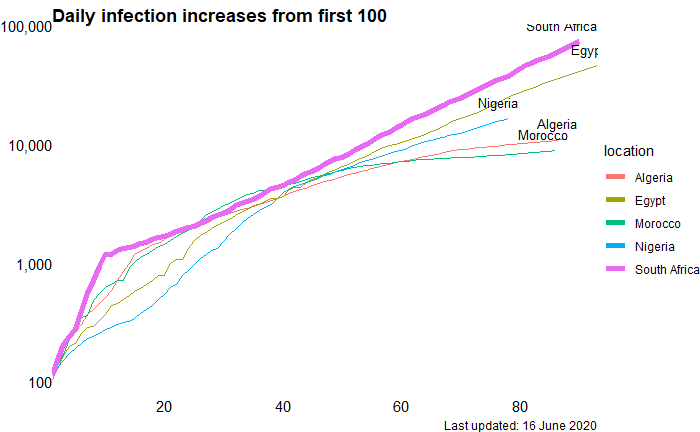

```r
  visualConfirmsPerMilAfrica # Graph
```

## 24. Africa - Infections and Deaths

The data for this table was sourced from the [European Centre for Disease Prevention and Control](https://github.com/owid/covid-19-data/tree/master/public/data).

```r
# Data transformation
  dataInfectionsDeathsAfrica <- rawGlobal %>%
    filter(continent == "Africa") %>%
    select(date, location, total_cases, total_deaths) %>%
    group_by(location) %>%
    top_n(1, total_cases) %>%
    distinct(date, location, total_cases, total_deaths) %>%
    top_n(1, date) %>%
    arrange(desc(total_cases)) %>%
    head(15)

  write_csv(dataInfectionsDeathsAfrica, path = "~/assignment1/data_out/infectionsDeathsAfrica.csv")

# Data visualisation
## Format headings for table
  headInfectionsDeathsAfrica <- dataInfectionsDeathsAfrica %>%
    select(location, total_cases, total_deaths) %>%
    rename(c("Country" = "location", "Cases" = "total_cases", "Deaths" = "total_deaths"))

## Creating the date caption for the visualisation
  captionInfectionsDeathsAfrica <- dataInfectionsDeathsAfrica %>%
    select(date) %>%
    filter(date == max(date)) %>%
    head(1) %>%
    mutate(date = as.character(date, format("%d %B %Y")))

  captionInfectionsDeathsAfrica  <- paste("Last updated:", captionInfectionsDeathsAfrica)

## Create table
  visualInfectionsDeathsAfrica <-  headInfectionsDeathsAfrica %>%
      kable(caption = "<h2><center><strong>Africa - Infections and Deaths</strong></center></h2>", align = "c") %>%
      kable_styling(bootstrap_options = "striped", full_width = F)%>%
      add_footnote(captionInfectionsDeathsAfrica)

  save_kable(visualInfectionsDeathsAfrica, file = "infectionsDeathsAfrica.png")

# Output
  dataInfectionsDeathsAfrica # Data
```

| date | location | total_cases | total_deaths |
| --- | --- | --- | --- |
| 2020-06-16 | South Africa | 73533 | 1568 |
| 2020-06-16 | Egypt | 46289 | 1672 |
| 2020-06-16 | Nigeria | 16658 | 424 |
| 2020-06-16 | Ghana | 11964 | 54 |
| 2020-06-16 | Algeria | 11031 | 777 |
| 2020-06-16 | Cameroon | 9864 | 276 |
| 2020-06-16 | Morocco | 8838 | 212 |
| 2020-06-16 | Sudan | 7220 | 459 |
| 2020-06-16 | Cote d'Ivoire | 5439 | 46 |
| 2020-06-16 | Senegal | 5173 | 64 |

[output cut: 5 more lines]

```r
  visualInfectionsDeathsAfrica # Table
```

| Country | Cases | Deaths |
| --- | --- | --- |
| South Africa | 73533 | 1568 |
| Egypt | 46289 | 1672 |
| Nigeria | 16658 | 424 |
| Ghana | 11964 | 54 |
| Algeria | 11031 | 777 |
| Cameroon | 9864 | 276 |
| Morocco | 8838 | 212 |
| Sudan | 7220 | 459 |
| Cote d'Ivoire | 5439 | 46 |
| Senegal | 5173 | 64 |
| Democratic Republic of Congo | 4837 | 112 |
| Guinea | 4572 | 26 |
| Djibouti | 4501 | 43 |
| Gabon | 4033 | 27 |
| Kenya | 3727 | 104 |

<sup>a</sup> Last updated: South Africa  
<sup>b</sup> Last updated: 16 June 2020